# R Project

-Ndertimi i grafikeve densitet.

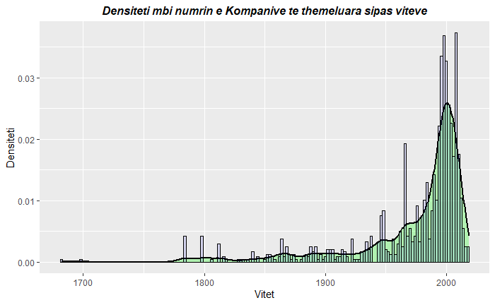

```r
library(ggplot2)

ggplot(data=data.analyst, aes(x=`Founded`))+geom_density(size=1.05, fill="green", alpha=0.25)+labs(y="Densiteti",x="Vitet",title = "Densiteti mbi numrin e Kompanive te themeluara sipas viteve") +theme(plot.title=element_text(color="black",face="bold.italic",size=12, hjust = 0.5))+geom_histogram(aes(y=..density..),binwidth=2, color="black", fill="blue", alpha=0.1)
```

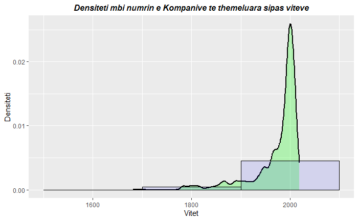

```r
library(ggplot2)

ggplot(data=data.analyst, aes(x=`Founded`))+geom_density(size=1.05, fill="green", alpha=0.25)+labs(y="Densiteti",x="Vitet",title = "Densiteti mbi numrin e Kompanive te themeluara sipas viteve") +theme(plot.title=element_text(color="black",face="bold.italic",size=12, hjust = 0.5))+geom_histogram(aes(y=..density..),binwidth=200, color="black", fill="blue", alpha=0.1)
```

Sic u siperpermend, periudha e “lulezimit” te kompanive ishin vitet 1980- 2005.

-Ndertimi i matrces se korrelacioneve. Le te marrim ne studim ndryshoret: Vitet e themelimit, Fitimin mesatar vjetor dhe numrin e punonjesve.

```r
library(corrplot)

library(dplyr)

Model <- data.analyst %>% select(Founded, `Average Revenue $`,`Number of employes`)

cor.mat=cor(Model)

cor.mat
```

```
                      Founded Average Revenue $ Number of employes
Founded             1.0000000        -0.4722601         -0.5472924
Average Revenue $  -0.4722601         1.0000000          0.5634794
Number of employes -0.5472924         0.5634794          1.0000000
```

Nga kjo analize ne mund te shohim vlera pozitive dhe negative te korrelimit te ndryshoreve te paraqitura. Bazuar ne keto vlera te paraqitura vihet re nje korrelacion i forte si pozitiv ashtu dhe negativ.

-Paraqitja grafike e matrices se korrelacionit

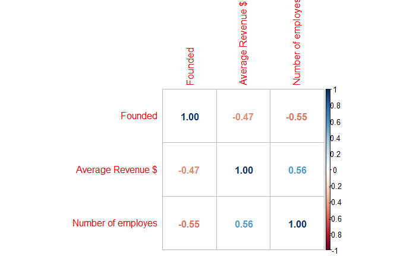

```r
library(corrplot)
corrplot(cor.mat, method = "number", type = "full")
```

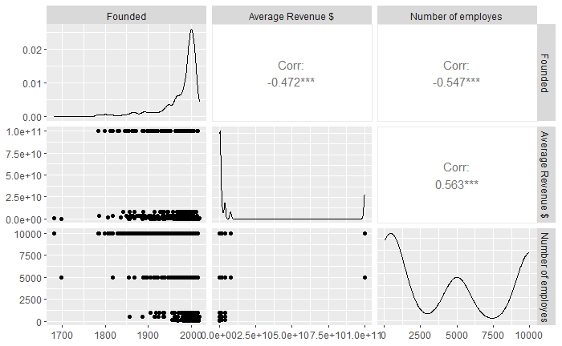

```r
ggpairs(Model)
```

```r
Model_reg <- lm(`Average Revenue $` ~ `Number of employes`, data = data.analyst)

summary(Model_reg)
```

```
Call:
lm(formula = `Average Revenue $` ~ `Number of employes`, data = data.analyst)

Residuals:
       Min         1Q     Median         3Q        Max
-4.259e+10 -1.818e+10  3.244e+09  4.764e+09  8.152e+10

Coefficients:
                       Estimate Std. Error t value Pr(>|t|)
(Intercept)          -5.654e+09  1.276e+09  -4.431 1.02e-05 ***
`Number of employes`  4.826e+06  2.050e+05  23.539  < 2e-16 ***
---
Signif. codes:  0 ‘***’ 0.001 ‘**’ 0.01 ‘*’ 0.05 ‘.’ 0.1 ‘ ’ 1

Residual standard error: 2.969e+10 on 1191 degrees of freedom
Multiple R-squared:  0.3175,    Adjusted R-squared:  0.3169
F-statistic: 554.1 on 1 and 1191 DF,  p-value: < 2.2e-16
```

-Ndertojme grafikun e regresit te thjeshte linear

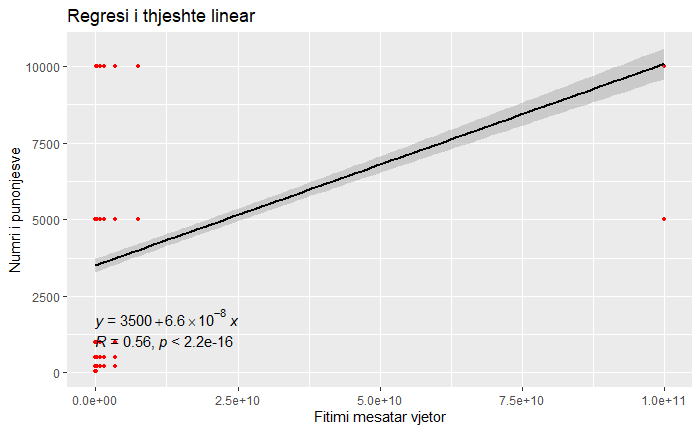

```r
library(ggpubr)

Graf<-ggplot(data.analyst, aes(x = `Average Revenue $`,y = `Number of employes`))+

  geom_point(size=1,color="red")+

  geom_smooth(method="lm",color="black",formula = y~x)+

  stat_cor(label.x = 0.5,label.y = 1000)+

  stat_regline_equation(label.x = 0.5,label.y = 1800, size=4)+

  labs(x="Fitimi mesatar vjetor",y="Numri i punonjesve",title="Regresi i thjeshte linear")

Graf
```

```
                                                    Tabelat e kontigjences
```

```r
Tab <- table(data.analyst$`Industry`, data.analyst$`Number of employes`)

addmargins(Tab)
```

```
                                              50  200  500 1000 5000 10000  Sum
  Accounting                                   1    0    3    1    0     3    8
  Advertising & Marketing                      4    7    1    5    2     3   22
  Aerospace & Defense                          0    1    3    1    1    13   19
  Architectural & Engineering Services         0    1    4    0    0     3    8
  Automotive Parts & Accessories Stores        0    0    0    0    2     2    4
  Banks & Credit Unions                        0    0    3    3   12    20   38
  Biotech & Pharmaceuticals                    2    0    0    2    4    13   21
  Brokerage Services                           0    0    0    0    2     0    2
  Building & Personnel Services                0    0    0    0    1     0    1
  Cable, Internet & Telephone Providers        0    0    0    1    0     3    4
  Chemical Manufacturing                       0    0    0    0    0     1    1
  Colleges & Universities                      0    0    2    0    3    16   21
  Commercial Equipment Repair & Maintenance    0    0    0    2    0     0    2
  Computer Hardware & Software                 6   10   10    4    4    39   73
  Construction                                 0    0    0    2    1     0    3
  Consulting                                   3   15    8   16    7     6   55
  Consumer Products Manufacturing              0    0    0    0    2     4    6
  Convenience Stores & Truck Stops             0    0    2    0    0     0    2
  Department, Clothing, & Shoe Stores          0    1    0    0    0     1    2
  Drug & Health Stores                         0    0    0    0    0     2    2
  Education Training Services                  0    1    0    2    0     0    3
  Electrical & Electronic Manufacturing        0    1    0    1    0     3    5
  Energy                                       0    2    0    1    2     0    5
  Enterprise Software & Network Solutions      4   14    8    5    4    11   46
  Federal Agencies                             0    0    6    0    0     0    6
  Financial Analytics & Research               0    0    0    0    1     1    2
  Financial Transaction Processing             0    3    1    1    1     4   10
  Food & Beverage Manufacturing                0    0    0    0    1     2    3
  Gambling                                     0    0    0    0    1     1    2
  Gas Stations                                 0    0    0    0    0     3    3
  General Merchandise & Superstores            0    0    0    0    0     3    3
  Grocery Stores & Supermarkets                0    0    0    0    0     3    3
  Health Care Products Manufacturing           0    1    0    0    1     3    5
  Health Care Services & Hospitals             1    5   14    4   19    45   88
  Health Fundraising Organizations             0    1    0    0    0     0    1
  Home Centers & Hardware Stores               0    0    0    0    0     4    4
  Industrial Manufacturing                     0    0    1    1    1     2    5
  Insurance Agencies & Brokerages              0    0    1    0    2     1    4
  Insurance Carriers                           0    0    2    3    8    22   35
```

[output cut: 18 more lines]

```
  Security Services                            0    0    0    0    0     2    2
  Social Assistance                            1    3    3    1    7     1   16
  Sports & Recreation                          0    1    0    1    0     0    2
  Staffing & Outsourcing                       9   57   29    9   76    44  224
  Stock Exchanges                              0    0    0    0    1     0    1
  Telecommunications Services                  0    2    0    0    2     2    6
  Transportation Equipment Manufacturing       0    0    0    0    0     3    3
  Transportation Management                    0    0    1    0    0     1    2
  Truck Rental & Leasing                       0    0    0    0    0     1    1
  TV Broadcast & Cable Networks                0    0    0    0    1     5    6
  Utilities                                    0    0    0    0    0     2    2
  Venture Capital & Private Equity             0    0    0    0    3     1    4
  Video Games                                  0    0    0    0    7     2    9
  Wholesale                                    0    1    2    1    1     1    6
  Sum                                         45  222  143  133  253   397 1193
```

-Tabela e frekuencave

```r
fTab <- prop.table(Tab)
addmargins(fTab)
```

```
                                                     50         200         500        1000        5000       10000         Sum
  Accounting                                0.000838223 0.000000000 0.002514669 0.000838223 0.000000000 0.002514669 0.006705784
  Advertising & Marketing                   0.003352892 0.005867561 0.000838223 0.004191115 0.001676446 0.002514669 0.018440905
  Aerospace & Defense                       0.000000000 0.000838223 0.002514669 0.000838223 0.000838223 0.010896899 0.015926236
  Architectural & Engineering Services      0.000000000 0.000838223 0.003352892 0.000000000 0.000000000 0.002514669 0.006705784
  Automotive Parts & Accessories Stores     0.000000000 0.000000000 0.000000000 0.000000000 0.001676446 0.001676446 0.003352892
  Banks & Credit Unions                     0.000000000 0.000000000 0.002514669 0.002514669 0.010058676 0.016764459 0.031852473
  Biotech & Pharmaceuticals                 0.001676446 0.000000000 0.000000000 0.001676446 0.003352892 0.010896899 0.017602682
  Brokerage Services                        0.000000000 0.000000000 0.000000000 0.000000000 0.001676446 0.000000000 0.001676446
  Building & Personnel Services             0.000000000 0.000000000 0.000000000 0.000000000 0.000838223 0.000000000 0.000838223
  Cable, Internet & Telephone Providers     0.000000000 0.000000000 0.000000000 0.000838223 0.000000000 0.002514669 0.003352892
  Chemical Manufacturing                    0.000000000 0.000000000 0.000000000 0.000000000 0.000000000 0.000838223 0.000838223
  Colleges & Universities                   0.000000000 0.000000000 0.001676446 0.000000000 0.002514669 0.013411567 0.017602682
  Commercial Equipment Repair & Maintenance 0.000000000 0.000000000 0.000000000 0.001676446 0.000000000 0.000000000 0.001676446
  Computer Hardware & Software              0.005029338 0.008382230 0.008382230 0.003352892 0.003352892 0.032690696 0.061190277
  Construction                              0.000000000 0.000000000 0.000000000 0.001676446 0.000838223 0.000000000 0.002514669
  Consulting                                0.002514669 0.012573345 0.006705784 0.013411567 0.005867561 0.005029338 0.046102263
  Consumer Products Manufacturing           0.000000000 0.000000000 0.000000000 0.000000000 0.001676446 0.003352892 0.005029338
  Convenience Stores & Truck Stops          0.000000000 0.000000000 0.001676446 0.000000000 0.000000000 0.000000000 0.001676446
  Department, Clothing, & Shoe Stores       0.000000000 0.000838223 0.000000000 0.000000000 0.000000000 0.000838223 0.001676446
  Drug & Health Stores                      0.000000000 0.000000000 0.000000000 0.000000000 0.000000000 0.001676446 0.001676446
  Education Training Services               0.000000000 0.000838223 0.000000000 0.001676446 0.000000000 0.000000000 0.002514669
  Electrical & Electronic Manufacturing     0.000000000 0.000838223 0.000000000 0.000838223 0.000000000 0.002514669 0.004191115
  Energy                                    0.000000000 0.001676446 0.000000000 0.000838223 0.001676446 0.000000000 0.004191115
  Enterprise Software & Network Solutions   0.003352892 0.011735122 0.006705784 0.004191115 0.003352892 0.009220453 0.038558256
  Federal Agencies                          0.000000000 0.000000000 0.005029338 0.000000000 0.000000000 0.000000000 0.005029338
  Financial Analytics & Research            0.000000000 0.000000000 0.000000000 0.000000000 0.000838223 0.000838223 0.001676446
  Financial Transaction Processing          0.000000000 0.002514669 0.000838223 0.000838223 0.000838223 0.003352892 0.008382230
  Food & Beverage Manufacturing             0.000000000 0.000000000 0.000000000 0.000000000 0.000838223 0.001676446 0.002514669
  Gambling                                  0.000000000 0.000000000 0.000000000 0.000000000 0.000838223 0.000838223 0.001676446
  Gas Stations                              0.000000000 0.000000000 0.000000000 0.000000000 0.000000000 0.002514669 0.002514669
  General Merchandise & Superstores         0.000000000 0.000000000 0.000000000 0.000000000 0.000000000 0.002514669 0.002514669
  Grocery Stores & Supermarkets             0.000000000 0.000000000 0.000000000 0.000000000 0.000000000 0.002514669 0.002514669
  Health Care Products Manufacturing        0.000000000 0.000838223 0.000000000 0.000000000 0.000838223 0.002514669 0.004191115
  Health Care Services & Hospitals          0.000838223 0.004191115 0.011735122 0.003352892 0.015926236 0.037720034 0.073763621
  Health Fundraising Organizations          0.000000000 0.000838223 0.000000000 0.000000000 0.000000000 0.000000000 0.000838223
  Home Centers & Hardware Stores            0.000000000 0.000000000 0.000000000 0.000000000 0.000000000 0.003352892 0.003352892
  Industrial Manufacturing                  0.000000000 0.000000000 0.000838223 0.000838223 0.000838223 0.001676446 0.004191115
  Insurance Agencies & Brokerages           0.000000000 0.000000000 0.000838223 0.000000000 0.001676446 0.000838223 0.003352892
  Insurance Carriers                        0.000000000 0.000000000 0.001676446 0.002514669 0.006705784 0.018440905 0.029337804
```

[output cut: 18 more lines]

```
  Security Services                         0.000000000 0.000000000 0.000000000 0.000000000 0.000000000 0.001676446 0.001676446
  Social Assistance                         0.000838223 0.002514669 0.002514669 0.000838223 0.005867561 0.000838223 0.013411567
  Sports & Recreation                       0.000000000 0.000838223 0.000000000 0.000838223 0.000000000 0.000000000 0.001676446
  Staffing & Outsourcing                    0.007544007 0.047778709 0.024308466 0.007544007 0.063704946 0.036881811 0.187761945
  Stock Exchanges                           0.000000000 0.000000000 0.000000000 0.000000000 0.000838223 0.000000000 0.000838223
  Telecommunications Services               0.000000000 0.001676446 0.000000000 0.000000000 0.001676446 0.001676446 0.005029338
  Transportation Equipment Manufacturing    0.000000000 0.000000000 0.000000000 0.000000000 0.000000000 0.002514669 0.002514669
  Transportation Management                 0.000000000 0.000000000 0.000838223 0.000000000 0.000000000 0.000838223 0.001676446
  Truck Rental & Leasing                    0.000000000 0.000000000 0.000000000 0.000000000 0.000000000 0.000838223 0.000838223
  TV Broadcast & Cable Networks             0.000000000 0.000000000 0.000000000 0.000000000 0.000838223 0.004191115 0.005029338
  Utilities                                 0.000000000 0.000000000 0.000000000 0.000000000 0.000000000 0.001676446 0.001676446
  Venture Capital & Private Equity          0.000000000 0.000000000 0.000000000 0.000000000 0.002514669 0.000838223 0.003352892
  Video Games                               0.000000000 0.000000000 0.000000000 0.000000000 0.005867561 0.001676446 0.007544007
  Wholesale                                 0.000000000 0.000838223 0.001676446 0.000838223 0.000838223 0.000838223 0.005029338
  Sum                                       0.037720034 0.186085499 0.119865884 0.111483655 0.212070411 0.332774518 1.000000000
```

-Tabela e frekuencave e paraqitur ne perqindje

```r
FTab <- prop.table(Tab)*100

FTab <- addmargins(FTab)

round(FTab, 3)
```

```
                                                 50     200     500    1000    5000   10000     Sum
  Accounting                                  0.084   0.000   0.251   0.084   0.000   0.251   0.671
  Advertising & Marketing                     0.335   0.587   0.084   0.419   0.168   0.251   1.844
  Aerospace & Defense                         0.000   0.084   0.251   0.084   0.084   1.090   1.593
  Architectural & Engineering Services        0.000   0.084   0.335   0.000   0.000   0.251   0.671
  Automotive Parts & Accessories Stores       0.000   0.000   0.000   0.000   0.168   0.168   0.335
  Banks & Credit Unions                       0.000   0.000   0.251   0.251   1.006   1.676   3.185
  Biotech & Pharmaceuticals                   0.168   0.000   0.000   0.168   0.335   1.090   1.760
  Brokerage Services                          0.000   0.000   0.000   0.000   0.168   0.000   0.168
  Building & Personnel Services               0.000   0.000   0.000   0.000   0.084   0.000   0.084
  Cable, Internet & Telephone Providers       0.000   0.000   0.000   0.084   0.000   0.251   0.335
  Chemical Manufacturing                      0.000   0.000   0.000   0.000   0.000   0.084   0.084
  Colleges & Universities                     0.000   0.000   0.168   0.000   0.251   1.341   1.760
  Commercial Equipment Repair & Maintenance   0.000   0.000   0.000   0.168   0.000   0.000   0.168
  Computer Hardware & Software                0.503   0.838   0.838   0.335   0.335   3.269   6.119
  Construction                                0.000   0.000   0.000   0.168   0.084   0.000   0.251
  Consulting                                  0.251   1.257   0.671   1.341   0.587   0.503   4.610
  Consumer Products Manufacturing             0.000   0.000   0.000   0.000   0.168   0.335   0.503
  Convenience Stores & Truck Stops            0.000   0.000   0.168   0.000   0.000   0.000   0.168
  Department, Clothing, & Shoe Stores         0.000   0.084   0.000   0.000   0.000   0.084   0.168
  Drug & Health Stores                        0.000   0.000   0.000   0.000   0.000   0.168   0.168
  Education Training Services                 0.000   0.084   0.000   0.168   0.000   0.000   0.251
  Electrical & Electronic Manufacturing       0.000   0.084   0.000   0.084   0.000   0.251   0.419
  Energy                                      0.000   0.168   0.000   0.084   0.168   0.000   0.419
  Enterprise Software & Network Solutions     0.335   1.174   0.671   0.419   0.335   0.922   3.856
  Federal Agencies                            0.000   0.000   0.503   0.000   0.000   0.000   0.503
  Financial Analytics & Research              0.000   0.000   0.000   0.000   0.084   0.084   0.168
  Financial Transaction Processing            0.000   0.251   0.084   0.084   0.084   0.335   0.838
  Food & Beverage Manufacturing               0.000   0.000   0.000   0.000   0.084   0.168   0.251
  Gambling                                    0.000   0.000   0.000   0.000   0.084   0.084   0.168
  Gas Stations                                0.000   0.000   0.000   0.000   0.000   0.251   0.251
  General Merchandise & Superstores           0.000   0.000   0.000   0.000   0.000   0.251   0.251
  Grocery Stores & Supermarkets               0.000   0.000   0.000   0.000   0.000   0.251   0.251
  Health Care Products Manufacturing          0.000   0.084   0.000   0.000   0.084   0.251   0.419
  Health Care Services & Hospitals            0.084   0.419   1.174   0.335   1.593   3.772   7.376
  Health Fundraising Organizations            0.000   0.084   0.000   0.000   0.000   0.000   0.084
  Home Centers & Hardware Stores              0.000   0.000   0.000   0.000   0.000   0.335   0.335
  Industrial Manufacturing                    0.000   0.000   0.084   0.084   0.084   0.168   0.419
  Insurance Agencies & Brokerages             0.000   0.000   0.084   0.000   0.168   0.084   0.335
  Insurance Carriers                          0.000   0.000   0.168   0.251   0.671   1.844   2.934
```

[output cut: 18 more lines]

```
  Security Services                           0.000   0.000   0.000   0.000   0.000   0.168   0.168
  Social Assistance                           0.084   0.251   0.251   0.084   0.587   0.084   1.341
  Sports & Recreation                         0.000   0.084   0.000   0.084   0.000   0.000   0.168
  Staffing & Outsourcing                      0.754   4.778   2.431   0.754   6.370   3.688  18.776
  Stock Exchanges                             0.000   0.000   0.000   0.000   0.084   0.000   0.084
  Telecommunications Services                 0.000   0.168   0.000   0.000   0.168   0.168   0.503
  Transportation Equipment Manufacturing      0.000   0.000   0.000   0.000   0.000   0.251   0.251
  Transportation Management                   0.000   0.000   0.084   0.000   0.000   0.084   0.168
  Truck Rental & Leasing                      0.000   0.000   0.000   0.000   0.000   0.084   0.084
  TV Broadcast & Cable Networks               0.000   0.000   0.000   0.000   0.084   0.419   0.503
  Utilities                                   0.000   0.000   0.000   0.000   0.000   0.168   0.168
  Venture Capital & Private Equity            0.000   0.000   0.000   0.000   0.251   0.084   0.335
  Video Games                                 0.000   0.000   0.000   0.000   0.587   0.168   0.754
  Wholesale                                   0.000   0.084   0.168   0.084   0.084   0.084   0.503
  Sum                                         3.772  18.609  11.987  11.148  21.207  33.277 100.000
```

-Grafiku mozaik

[figure not shown]

```r
mosaicplot( Tab, col = c("firebrick", "#ffa700"), cex.axis = 1, sub = "Sektori i veprimtarise", ylab = "Denduria relative", main = "")
```